# curvana: a comprehensive R package for analyzing atomic force microscopy force–distance curves

Tutorial

Yue (Gary) Zhang, PhD

2026-03-10

```r
knitr::opts_chunk$set(warning = T, message = T,echo = T)
```

# Introduction

This tutorial demonstrates the full analytical workflow of the **curvana** R package, from raw AFM deflection–displacement curves to transformed force–distance curves and their analytical metrics, such as adhesive force, interaction energy and rupture and repulsive distance.

# Preparation

## Initializing work environment

```r
required_packages = c('curvana', 'ggplot2', 'DT', 'dplyr', 'cowplot')
optional_packages = c('ggpubr')

missing_required <- required_packages[!vapply(required_packages, requireNamespace, logical(1), quietly = TRUE)]
if (length(missing_required) > 0) {
  stop('Please install required packages first: ', paste(missing_required, collapse = ', '))
}

invisible(suppressPackageStartupMessages({
  lapply(required_packages, library, character.only = TRUE)
}))

available_optional <- optional_packages[vapply(optional_packages, requireNamespace, logical(1), quietly = TRUE)]
if (length(available_optional) > 0) {
  invisible(suppressPackageStartupMessages({
    lapply(available_optional, library, character.only = TRUE)
  }))
} else {
  message("Optional package 'ggpubr' is not installed; statistical annotation examples will be skipped.")
}

source(system.file("tutorial_helpers.R", package = "curvana"))
```

## Load demo data

All examples below use the demo dataset provided in `extdata/` inside the package. To use your own dataset, you can pass the path to the directory holding the data to the “folder” argument. Note that users can increase the threads to enable parallel processing for loading a large folder (e.g., > 5000 curves), which will dramatically reduce the computational time.

At this step, we initialize the fdObj named “test” by importing the demo data directory “extdata/” using the “createFdObjFromFolder” function. An fdObj is the core data container in curvana, designed to store atomic force microscopy (AFM) force–distance curve data, including raw approach and retract curves, transformed data, associated metadata for downstream analysis, and the analytical metrics generated.

By default, createFdObjFromFolder will read all files in the designated folder with suffix “.txt”, and expect each file has paired approach and retract deflection-dislocation raw curve data with standard column names (i.e., Calc_Ramp_Ex_nm, Defl_V_Ex, Calc_Ramp_Rt_nm, Defl_V_Rt).

Users working with non-standard input files can specify column headers. User may also use the “suffix” argument to specify files to import by specifying filename suffix, or by providing a metadata dataframe whose row names match the input file names. Please note that the input files have to be tab-delimited files. See package manual for detailed usage.

```r
folder = system.file("extdata", package = "curvana")
t = 1
test.input = createFdObjFromFolder(folder = folder, threads = t)
```

Let’s take a quick look at the fdObj (named test) we created. We can see that we imported 768 raw curves. Non of them are transformed yet, and “filename” is the only column in the metadata slot.

```r
print(test.input)
```

```
## An object of class "fdObj"
## ----------------------------------------
## Samples registered:  768
## Raw curves imported:  768
## Transformed approach curves:  0
## Transformed retract curves:   0
##
## Metadata columns:
##   - filename
```

```r
view_df(test.input@metadata,'metadata')
```

|  | filename |
| --- | --- |
| F_1.spm-F4E1_ForceCurveIndex_0.spm | F_1.spm-F4E1_ForceCurveIndex_0.spm |
| F_1.spm-F4E1_ForceCurveIndex_1.spm | F_1.spm-F4E1_ForceCurveIndex_1.spm |
| F_1.spm-F4E1_ForceCurveIndex_10.spm | F_1.spm-F4E1_ForceCurveIndex_10.spm |
| F_1.spm-F4E1_ForceCurveIndex_11.spm | F_1.spm-F4E1_ForceCurveIndex_11.spm |
| F_1.spm-F4E1_ForceCurveIndex_12.spm | F_1.spm-F4E1_ForceCurveIndex_12.spm |
| F_1.spm-F4E1_ForceCurveIndex_13.spm | F_1.spm-F4E1_ForceCurveIndex_13.spm |
| F_1.spm-F4E1_ForceCurveIndex_14.spm | F_1.spm-F4E1_ForceCurveIndex_14.spm |
| F_1.spm-F4E1_ForceCurveIndex_15.spm | F_1.spm-F4E1_ForceCurveIndex_15.spm |
| F_1.spm-F4E1_ForceCurveIndex_16.spm | F_1.spm-F4E1_ForceCurveIndex_16.spm |
| F_1.spm-F4E1_ForceCurveIndex_17.spm | F_1.spm-F4E1_ForceCurveIndex_17.spm |

[output cut: 758 more lines]

## Manipulate the fdObj object

The demo dataset has measurements made on different surface at different regions. Let’s group them in the metadata.

```r
test <- test.input
test@metadata <- test@metadata %>%
  mutate(surface = sub("_.*","",filename),
         surface = case_when(
            surface == 'F' ~ 'fluorinated',
            surface == 'P' ~ 'PEG',
            surface == 'silicon' ~ 'silicon',
            surface == 'Z' ~ 'zwitterionic',
            TRUE ~ surface),
         region = sub(".*?_([0-9]+)\\.spm.*", "\\1", filename)
  )
view_df(test@metadata,'metadata')
```

|  | filename | surface | region |
| --- | --- | --- | --- |
| F_1.spm-F4E1_ForceCurveIndex_0.spm | F_1.spm-F4E1_ForceCurveIndex_0.spm | fluorinated | 1 |
| F_1.spm-F4E1_ForceCurveIndex_1.spm | F_1.spm-F4E1_ForceCurveIndex_1.spm | fluorinated | 1 |
| F_1.spm-F4E1_ForceCurveIndex_10.spm | F_1.spm-F4E1_ForceCurveIndex_10.spm | fluorinated | 1 |
| F_1.spm-F4E1_ForceCurveIndex_11.spm | F_1.spm-F4E1_ForceCurveIndex_11.spm | fluorinated | 1 |
| F_1.spm-F4E1_ForceCurveIndex_12.spm | F_1.spm-F4E1_ForceCurveIndex_12.spm | fluorinated | 1 |
| F_1.spm-F4E1_ForceCurveIndex_13.spm | F_1.spm-F4E1_ForceCurveIndex_13.spm | fluorinated | 1 |
| F_1.spm-F4E1_ForceCurveIndex_14.spm | F_1.spm-F4E1_ForceCurveIndex_14.spm | fluorinated | 1 |
| F_1.spm-F4E1_ForceCurveIndex_15.spm | F_1.spm-F4E1_ForceCurveIndex_15.spm | fluorinated | 1 |
| F_1.spm-F4E1_ForceCurveIndex_16.spm | F_1.spm-F4E1_ForceCurveIndex_16.spm | fluorinated | 1 |
| F_1.spm-F4E1_ForceCurveIndex_17.spm | F_1.spm-F4E1_ForceCurveIndex_17.spm | fluorinated | 1 |

[output cut: 758 more lines]

```r
test_beforeTransform <- test
```

It is also possible to extract specific samples from an fdObj either by providing their sample names (i.e., row names in the metadata) or by subsetting the object based on conditions applied to metadata columns.

```r
test.peg = extract(test,by_col = list(surface = "PEG"))
test.silicon = extract(test,by_sample = rownames(test@metadata[test@metadata$surface == 'silicon',]))
```

Just as we might need to subset a fdObj, we might also need to combine two fdObjs (e.g., from different experiments). The “combine” function is designed for this purpose. Note that if there are overlapping samples between the two fdObjs being combined, the “combine” function will return an error.

```r
test.combine.1 = combineFdObj(test.peg,test.silicon)
#test.combine.2 = combineFdObj(test.paeru,test.paeru2) # should return error
```

## Preview the raw deflection curves

It is important to inspect the raw curves before formal analysis. We can use the “plot_deflection_curves” function to plot curves in batch. Here, we split curves into sub-panels by column “surface”, and color code them by column “region”.

```
## 768 samples in the input; 768 approach and 768 retract curves are plotted.
```

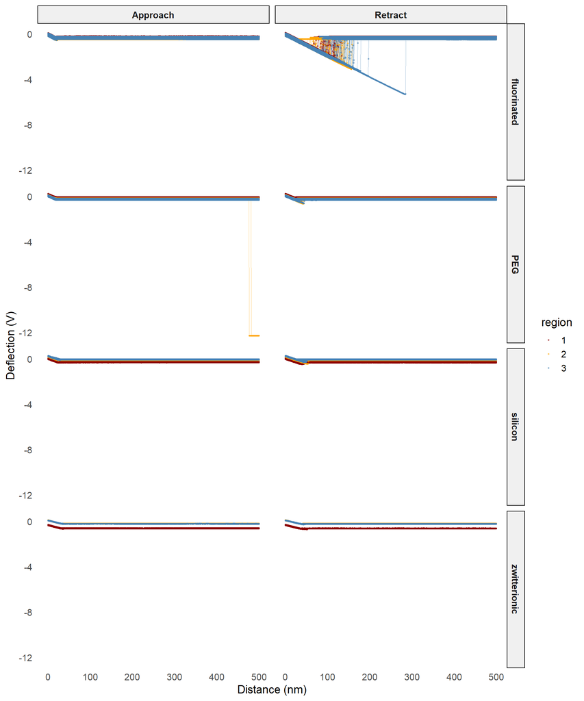

```r
plot_deflection_curves(test,split_curves_by = 'surface',group_curves_by = 'region',
                       alpha = 0.5,point_size = 0.5,
                       color_map = list(`1` = 'darkred',
                                        `2` = 'orange',
                                        `3` = 'steelblue'))
```

# Curve transformation

One advantage of curvana is that each step of the data analysis is modularized, enabling a flexible and customizable workflow. Curve transformation in curvana involves several steps, including sensitivity calculation, baseline offset calculation, and the application of these parameters to convert raw data into interaction force–separation distance curves. In this section, we demonstrate how to apply a wrapper function to transform all curves at once, as well as how each curve is transformed internally under the hood.

## Transform curves using the wrapper function “transform_curves”

At this step, we calculate the baseline and sensitivity of each raw AFM curve and transform the deflection-dislocation data into calibrated force–distance curves. The wrapper function transform_curves() automates this process by internally calling analyze_sensitivity() and analyze_baseline() to estimate the sensitivity and baseline values when their corresponding columns are not yet present in the metadata.

To transform a curve, the spring constant of the AFM probe is required to convert deflection (V) to force (nN). The transform_curves() function accepts either a single numeric value, applied to all curves and stored in metadata$spring_constant, or a metadata column name containing per-curve spring constants. These values are then used with the computed baseline and sensitivity to generate the final force–distance curves.After these parameters are obtained, the function applies them to transform each curve into its calibrated form. All arguments accepted by analyze_sensitivity() and analyze_baseline() can be passed directly to transform_curves(), allowing full control over the analysis parameters.

Here we set the spring constant to 0.08 N/m for all curves, and set the least length of of the curve for baseline calculation to 200, which means the function will use the last 200 points of each curve to calculate the baseline offset. We also set the slope threshold to 0.01 and standard deviation threshold to 0.01 for filtering out curves with unstable baseline. For sensitivity calculation, as we have a small contact region, we set end = 20 to only use the first 20 points of the curve to calculate sensitivity.

```r
t = 1
# test_beforeTransform -> test
test = transform_curves(test,spring_constant = 0.08,useCurve = 'approach',threads = t, least_length = 200, slp_threshold = 0.01, std_threshold = 0.01, end = 20)
```

```
## Using fixed spring constant: 0.0800 nN/nm (stored in metadata$spring_constant).
```

```
## Column 'sensitivity_V_nm_approach' not found in metadata. Running analyze_sensitivity()...
```

```
## Processed 768 curves; 0 failed sensitivity calculation.
```

```
## Column 'baseline_V_approach' not found in metadata. Running analyze_baseline()...
```

```
## Processed 768 curves; 2 failed baseline detection.
```

```
## Processed 768 curves (approach); 2 failed transformation.
```

```r
test = transform_curves(test,spring_constant = 0.08,useCurve = 'retract',threads = t, least_length = 200, slp_threshold = 0.01, std_threshold = 0.01, end = 20)
```

```
## Using fixed spring constant: 0.0800 nN/nm (stored in metadata$spring_constant).
```

```
## Column 'sensitivity_V_nm_retract' not found in metadata. Running analyze_sensitivity()...
```

```
## Processed 768 curves; 0 failed sensitivity calculation.
```

```
## Column 'baseline_V_retract' not found in metadata. Running analyze_baseline()...
```

```
## Processed 768 curves; 0 failed baseline detection.
```

```
## Processed 768 curves (retract); 0 failed transformation.
```

## Examine the object after transformation

We can see that now we have curves transformed.

```r
print(test)
```

```
## An object of class "fdObj"
## ----------------------------------------
## Samples registered:  768
## Raw curves imported:  768
## Transformed approach curves:  766
## Transformed retract curves:   768
##
## Metadata columns:
##   - filename
##   - surface
##   - region
##   - spring_constant
##   - sensitivity_V_nm_approach
##   - baseline_V_approach
##   - baseline_span_approach
##   - sensitivity_V_nm_retract
##   - baseline_V_retract
##   - baseline_span_retract
```

The transformed curves are stored in the retractCurves and approachCurves slots of the fdObj. Note that when the sensitivity or baseline cannot be reliably determined—such as in curves with highly fluctuating probe–surface contact regions or irregular baseline segments—the transformation will fail. In these cases, the corresponding entry in the transformed curve slot (retractCurves or approachCurves) is stored as an empty data frame with zero rows, indicating an unsuccessful transformation.

```r
print(names(test@retractCurves)%>% head())
```

```
## [1] "F_1.spm-F4E1_ForceCurveIndex_0.spm"  "F_1.spm-F4E1_ForceCurveIndex_1.spm"
## [3] "F_1.spm-F4E1_ForceCurveIndex_10.spm" "F_1.spm-F4E1_ForceCurveIndex_11.spm"
## [5] "F_1.spm-F4E1_ForceCurveIndex_12.spm" "F_1.spm-F4E1_ForceCurveIndex_13.spm"
```

```r
print(names(test@approachCurves)%>% head())
```

```
## [1] "F_1.spm-F4E1_ForceCurveIndex_0.spm"  "F_1.spm-F4E1_ForceCurveIndex_1.spm"
## [3] "F_1.spm-F4E1_ForceCurveIndex_10.spm" "F_1.spm-F4E1_ForceCurveIndex_11.spm"
## [5] "F_1.spm-F4E1_ForceCurveIndex_12.spm" "F_1.spm-F4E1_ForceCurveIndex_13.spm"
```

The calculated sensitivity, baseline, and input spring constant is now saved as columns in the metadata. Note the curves with baseline/sensitivity undetermined will be missing in the corresponding cell.

```r
view_df(test@metadata,'metadata after curve transformation')
```

|  | filename | surface | region | spring_constant | sensitivity_V_nm_approach | baseline_V_approach | baseline_span_approach | sensitivity_V_nm_retract | baseline_V_retract | baseline_span_retract |
| --- | --- | --- | --- | --- | --- | --- | --- | --- | --- | --- |
| F_1.spm-F4E1_ForceCurveIndex_0.spm | F_1.spm-F4E1_ForceCurveIndex_0.spm | fluorinated | 1 | 0.08 | 0.01953641861105479 | -0.229565625 | 200 | 0.01854091533778227 | -0.232640625 | 200 |
| F_1.spm-F4E1_ForceCurveIndex_1.spm | F_1.spm-F4E1_ForceCurveIndex_1.spm | fluorinated | 1 | 0.08 | 0.01920264564432838 | -0.22657125 | 200 | 0.01851436154639396 | -0.23208 | 200 |
| F_1.spm-F4E1_ForceCurveIndex_10.spm | F_1.spm-F4E1_ForceCurveIndex_10.spm | fluorinated | 1 | 0.08 | 0.01941485563269295 | -0.256685625 | 200 | 0.01848717328118599 | -0.261721875 | 200 |
| F_1.spm-F4E1_ForceCurveIndex_11.spm | F_1.spm-F4E1_ForceCurveIndex_11.spm | fluorinated | 1 | 0.08 | 0.01965706223446964 | -0.252429375 | 200 | 0.01840344476627398 | -0.257529375 | 200 |
| F_1.spm-F4E1_ForceCurveIndex_12.spm | F_1.spm-F4E1_ForceCurveIndex_12.spm | fluorinated | 1 | 0.08 | 0.01902592015882531 | -0.247531875 | 200 | 0.01818141302394612 | -0.254184375 | 200 |
| F_1.spm-F4E1_ForceCurveIndex_13.spm | F_1.spm-F4E1_ForceCurveIndex_13.spm | fluorinated | 1 | 0.08 | 0.01778687873010514 | -0.24501 | 200 | 0.01822792854473789 | -0.249594375 | 200 |
| F_1.spm-F4E1_ForceCurveIndex_14.spm | F_1.spm-F4E1_ForceCurveIndex_14.spm | fluorinated | 1 | 0.08 | 0.01901381426265763 | -0.23634 | 200 | 0.01822647362597969 | -0.24580875 | 200 |
| F_1.spm-F4E1_ForceCurveIndex_15.spm | F_1.spm-F4E1_ForceCurveIndex_15.spm | fluorinated | 1 | 0.08 | 0.01953064530288553 | -0.23235 | 200 | 0.01887154553664976 | -0.23813625 | 200 |
| F_1.spm-F4E1_ForceCurveIndex_16.spm | F_1.spm-F4E1_ForceCurveIndex_16.spm | fluorinated | 1 | 0.08 | 0.01943848205592498 | -0.287461875 | 200 | 0.0184477520035663 | -0.290833125 | 200 |
| F_1.spm-F4E1_ForceCurveIndex_17.spm | F_1.spm-F4E1_ForceCurveIndex_17.spm | fluorinated | 1 | 0.08 | 0.01934580236365969 | -0.283858125 | 200 | 0.01840544552819708 | -0.287653125 | 200 |

[output cut: 758 more lines]

## Plot transformed curves

```
## 768 samples in the input; 766 approach and 768 retract curves are plotted.
```

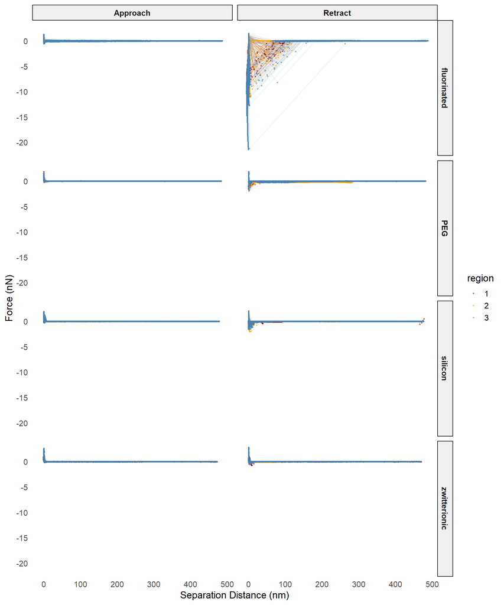

```r
plot_fd_curves(test,group_curves_by = 'region', split_curves_by = 'surface',
               point_alpha = 0.5,line_alpha = 0.3, point_size = 0.5,
               color_map = list(`1` = 'darkred',
                                `2` = 'orange',
                                `3` = 'steelblue'))
```

We can see that Fluorinated surface has the largest adhesion, which occurs mostly immediately after pulling probe off the surface. The other surfaces also have adhesion, but the magnitude of adhesion is smaller. All curves passed the transformation step have a baseline that is well aligned with the zero-force line with a relatively small fluctuation, which is important for accurate calculation of analytical metrics in later steps.

## Single curve transformation

### Sensitivity calculation

To demonstrate how each single curve is transformed, we take the retract part of “silicon_wafer_2.spm-2658_ForceCurveIndex_36.spm” as an example. The function “calc_sensitivity”, adapted from fdafm (Zhang et al., 2021), is designed to automatically to calculate the sensitivity value. Note that the function returns two outputs – the sensitivity value, and the subset of data points used to calculate the sensitivity value (the second element of the returned list, which is a named dataframe named senscal_segment).

For sensitivity calculation, as mentioned above, we set end = 20 to only use the first 20 points of the curve to calculate sensitivity. This is because for this experiment we have a short contact region in the curve.

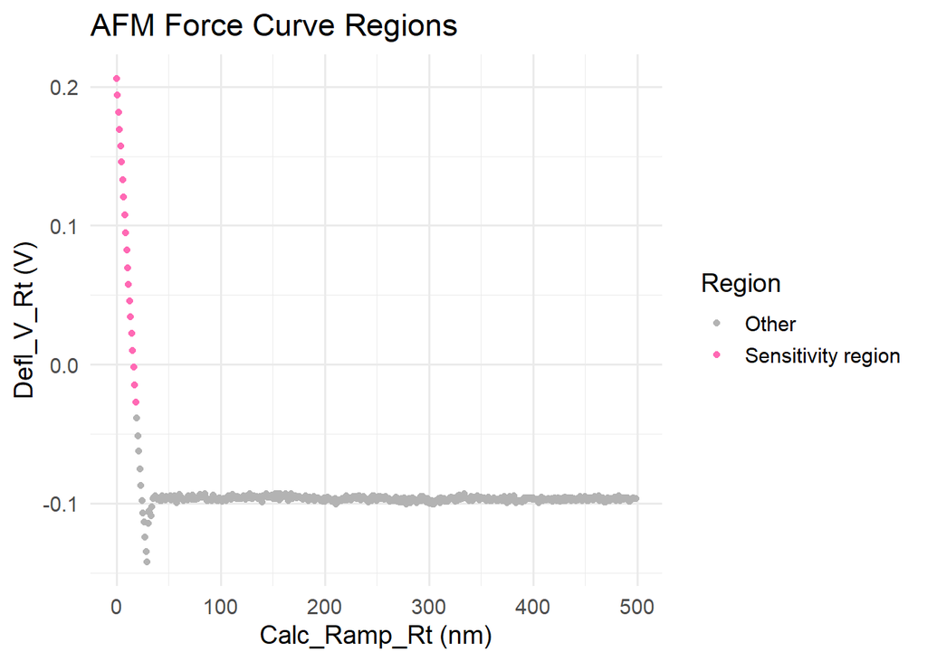

```r
#example1.name = '180424_fv_pmon2_loc1-18-22.spm'
example1.name = 'silicon_wafer_2.spm-2658_ForceCurveIndex_36.spm'
example1.raw = test@rawCurves[[example1.name]]

x = example1.raw$Calc_Ramp_Rt_nm
y = example1.raw$Defl_V_Rt
res.sens = calc_sensitivity(end = 20, x = x, y = y)
example1.raw$`Region used for Sensitivity calculation` = case_when(example1.raw$Calc_Ramp_Rt_nm %in% res.sens$senscal_segment$x ~ "Sensitivity region", TRUE ~ "Other")

ggplot(example1.raw, aes(x = Calc_Ramp_Rt_nm, y = Defl_V_Rt)) +
  geom_point(aes(
    color = `Region used for Sensitivity calculation`  ), size = 1.5) +
  scale_color_manual(
    values = c(
      "Sensitivity region" = "hotpink",
      "Other" = "grey70"
    ),
    name = "Region"
  ) +
  labs(
    x = "Calc_Ramp_Rt (nm)",
    y = "Defl_V_Rt (V)",
    title = "AFM Force Curve Regions"
  ) +
  theme_minimal(base_size = 14)
```

To analyze the sensitivity value for all curves in the object at once, we can run function “analyze_sensitivity.” The function internally executes “calc_sensitivity” for each curve separately, and record the sensitivity value of each curve in a metadata column named “sensitivity_V_nm_dir”, where dir is the selected curve portion via useCurve argument (either “approach” or “retract”).

Curves that failed in sensitivity calculation will have an ‘NA’ in their corresponding cells. The segment of each raw curve used for sensitivity calculation is saved in the object’s slot named “senscal_segment”.

```r
test2 = analyze_sensitivity(test_beforeTransform,useCurve = 'approach',threads = 1,end = 20)
```

```
## Processed 768 curves; 0 failed sensitivity calculation.
```

```r
test2 = analyze_sensitivity(test2,useCurve = 'retract',threads = 1,end = 20)
```

```
## Processed 768 curves; 0 failed sensitivity calculation.
```

```r
view_df(test2@metadata,'metadata with sensitivity values added as columns')
```

|  | filename | surface | region | sensitivity_V_nm_approach | sensitivity_V_nm_retract |
| --- | --- | --- | --- | --- | --- |
| F_1.spm-F4E1_ForceCurveIndex_0.spm | F_1.spm-F4E1_ForceCurveIndex_0.spm | fluorinated | 1 | 0.01953641861105479 | 0.01854091533778227 |
| F_1.spm-F4E1_ForceCurveIndex_1.spm | F_1.spm-F4E1_ForceCurveIndex_1.spm | fluorinated | 1 | 0.01920264564432838 | 0.01851436154639396 |
| F_1.spm-F4E1_ForceCurveIndex_10.spm | F_1.spm-F4E1_ForceCurveIndex_10.spm | fluorinated | 1 | 0.01941485563269295 | 0.01848717328118599 |
| F_1.spm-F4E1_ForceCurveIndex_11.spm | F_1.spm-F4E1_ForceCurveIndex_11.spm | fluorinated | 1 | 0.01965706223446964 | 0.01840344476627398 |
| F_1.spm-F4E1_ForceCurveIndex_12.spm | F_1.spm-F4E1_ForceCurveIndex_12.spm | fluorinated | 1 | 0.01902592015882531 | 0.01818141302394612 |
| F_1.spm-F4E1_ForceCurveIndex_13.spm | F_1.spm-F4E1_ForceCurveIndex_13.spm | fluorinated | 1 | 0.01778687873010514 | 0.01822792854473789 |
| F_1.spm-F4E1_ForceCurveIndex_14.spm | F_1.spm-F4E1_ForceCurveIndex_14.spm | fluorinated | 1 | 0.01901381426265763 | 0.01822647362597969 |
| F_1.spm-F4E1_ForceCurveIndex_15.spm | F_1.spm-F4E1_ForceCurveIndex_15.spm | fluorinated | 1 | 0.01953064530288553 | 0.01887154553664976 |
| F_1.spm-F4E1_ForceCurveIndex_16.spm | F_1.spm-F4E1_ForceCurveIndex_16.spm | fluorinated | 1 | 0.01943848205592498 | 0.0184477520035663 |
| F_1.spm-F4E1_ForceCurveIndex_17.spm | F_1.spm-F4E1_ForceCurveIndex_17.spm | fluorinated | 1 | 0.01934580236365969 | 0.01840544552819708 |

[output cut: 758 more lines]

### Baseline offsets

Similarly, the offset voltage of each curve can be estimated using the find_baseline() function. We assume that the far-right region of every curve corresponds to the probe being fully detached from the surface and therefore free from interaction forces. The mean of the y values of the last N points (defined by the least_length argument) in this region is calculated as the baseline offset value that will be used in later steps to move the curve up or down to align with the zero-force line (i.e., x axis). Here we set the least length of the curves to 200. We set slope threshold to 0.01 and standard deviation threshold to 0.01, meaning the curve will be discarded if the last 200 points has a standard deviation of y-value greater than 0.01 or its linear regression has a slope greater than 0.01.

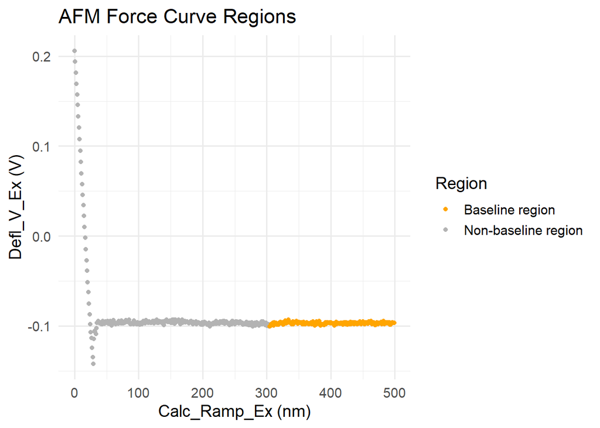

```r
res.base = find_baseline(x = x, y = y,  sensitivity = res.sens$sensitivity, least_length = 200,slp_threshold = 0.01,std_threshold = 0.01)
example1.raw$`Region used for baseline offset calculation` = case_when(example1.raw$Calc_Ramp_Rt_nm %in% res.base$segment$x ~ "Baseline region", TRUE ~ "Non-baseline region")

ggplot(example1.raw, aes(x = Calc_Ramp_Rt_nm, y = Defl_V_Rt)) +
  geom_point(aes(color = `Region used for baseline offset calculation`), size = 1.5) +
  scale_color_manual(
    values = c(
      "Baseline region" = "orange",
      "Non-baseline region" = "grey70"
    ),
    name = "Region"
  ) +
  labs(
    x = "Calc_Ramp_Ex (nm)",
    y = "Defl_V_Ex (V)",
    title = "AFM Force Curve Regions"
  ) +
  theme_minimal(base_size = 14)
```

To analyze the baseline offset for each curve in an fdObj, we use the analyze_baseline() function. This function internally calls find_baseline() for each curve and records the computed baseline offset values in the metadata columns “baseline_V_dir”, along with the length of the baseline segment defined by the user. The portions of each raw curve used for baseline offset estimation are stored in the baseline_segment slot of the object.

Curves can exhibit undulating or unstable baselines. Such abnormal curves—identified by a slope greater than slp_threshold and a standard deviation greater than std_threshold—are considered unreliable and are omitted from subsequent analyses. Curves that fail baseline calculation are assigned NA in these metadata columns. The analyze_baseline function will automatically look up the sensitivity columns generated in analyze_sensitivity. Since baseline estimation requires a valid sensitivity value, any curve that fails sensitivity calculation (i.e., does not have a numeric sensitivity value in the corresponding metadata column) will also fail baseline calculation.

```r
test2 = analyze_baseline(test2,useCurve = 'approach',least_length = 200,slp_threshold = 0.01,std_threshold = 0.01)
```

```
## Processed 768 curves; 2 failed baseline detection.
```

```r
test2 = analyze_baseline(test2,useCurve = 'retract', least_length = 200,slp_threshold = 0.01,std_threshold = 0.01)
```

```
## Processed 768 curves; 0 failed baseline detection.
```

```r
view_df(test2@metadata,'metadata with baseline values added as columns')
```

|  | filename | surface | region | sensitivity_V_nm_approach | sensitivity_V_nm_retract | baseline_V_approach | baseline_span_approach | baseline_V_retract | baseline_span_retract |
| --- | --- | --- | --- | --- | --- | --- | --- | --- | --- |
| F_1.spm-F4E1_ForceCurveIndex_0.spm | F_1.spm-F4E1_ForceCurveIndex_0.spm | fluorinated | 1 | 0.01953641861105479 | 0.01854091533778227 | -0.229565625 | 200 | -0.232640625 | 200 |
| F_1.spm-F4E1_ForceCurveIndex_1.spm | F_1.spm-F4E1_ForceCurveIndex_1.spm | fluorinated | 1 | 0.01920264564432838 | 0.01851436154639396 | -0.22657125 | 200 | -0.23208 | 200 |
| F_1.spm-F4E1_ForceCurveIndex_10.spm | F_1.spm-F4E1_ForceCurveIndex_10.spm | fluorinated | 1 | 0.01941485563269295 | 0.01848717328118599 | -0.256685625 | 200 | -0.261721875 | 200 |
| F_1.spm-F4E1_ForceCurveIndex_11.spm | F_1.spm-F4E1_ForceCurveIndex_11.spm | fluorinated | 1 | 0.01965706223446964 | 0.01840344476627398 | -0.252429375 | 200 | -0.257529375 | 200 |
| F_1.spm-F4E1_ForceCurveIndex_12.spm | F_1.spm-F4E1_ForceCurveIndex_12.spm | fluorinated | 1 | 0.01902592015882531 | 0.01818141302394612 | -0.247531875 | 200 | -0.254184375 | 200 |
| F_1.spm-F4E1_ForceCurveIndex_13.spm | F_1.spm-F4E1_ForceCurveIndex_13.spm | fluorinated | 1 | 0.01778687873010514 | 0.01822792854473789 | -0.24501 | 200 | -0.249594375 | 200 |
| F_1.spm-F4E1_ForceCurveIndex_14.spm | F_1.spm-F4E1_ForceCurveIndex_14.spm | fluorinated | 1 | 0.01901381426265763 | 0.01822647362597969 | -0.23634 | 200 | -0.24580875 | 200 |
| F_1.spm-F4E1_ForceCurveIndex_15.spm | F_1.spm-F4E1_ForceCurveIndex_15.spm | fluorinated | 1 | 0.01953064530288553 | 0.01887154553664976 | -0.23235 | 200 | -0.23813625 | 200 |
| F_1.spm-F4E1_ForceCurveIndex_16.spm | F_1.spm-F4E1_ForceCurveIndex_16.spm | fluorinated | 1 | 0.01943848205592498 | 0.0184477520035663 | -0.287461875 | 200 | -0.290833125 | 200 |
| F_1.spm-F4E1_ForceCurveIndex_17.spm | F_1.spm-F4E1_ForceCurveIndex_17.spm | fluorinated | 1 | 0.01934580236365969 | 0.01840544552819708 | -0.283858125 | 200 | -0.287653125 | 200 |

[output cut: 758 more lines]

## Transformation of a raw curve

Now, with the sensitivity and baseline offset values calculated, we are ready to transform the curve with function transform_a_curve. senscal_seg_x and senscal_seg_y are the x and y values of the segment used for sensitivity calculation, which also will be used for curve transformation.

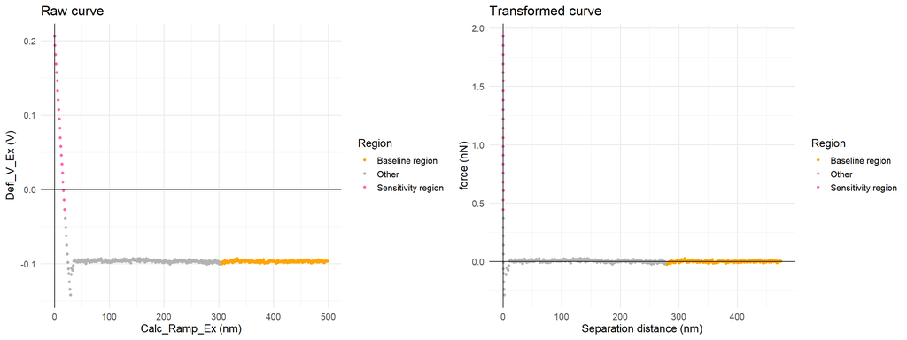

```r
example1.transformed = transform_a_curve(x = x, y= y, baseline = res.base$baseline, sensitivity = res.sens$sensitivity,
                             spring_constant = 0.08, senscal_seg_x = res.sens$senscal_segment$x,
                             senscal_seg_y = res.sens$senscal_segment$y)

p1 = ggplot(example1.raw, aes(x = Calc_Ramp_Rt_nm, y = Defl_V_Rt)) +
  geom_point(aes(
    color = case_when(
      `Region used for Sensitivity calculation` == 'Sensitivity region' ~ "Sensitivity region",
      `Region used for baseline offset calculation` == 'Baseline region' ~ "Baseline region",
      TRUE ~ "Other"
    )
  ), size = 1.5) +
  scale_color_manual(
    values = c(
      "Sensitivity region" = "hotpink",
      "Baseline region" = "orange",
      "Other" = "grey70"
    ),
    name = "Region"
  ) +
  labs(
    x = "Calc_Ramp_Ex (nm)",
    y = "Defl_V_Ex (V)",
    title = "Raw curve"
  ) +
  theme_minimal(base_size = 14) +
  geom_hline(yintercept = 0, color = "black", linewidth = 0.5) +
  geom_vline(xintercept = 0, color = "black", linewidth = 0.5)


example1.transformed = cbind(example1.transformed, example1.raw[,c('Region used for Sensitivity calculation','Region used for baseline offset calculation')])
p2 = ggplot(example1.transformed, aes(x = separation_distance_nm, y = force_nN)) +
  geom_point(aes(
    color = case_when(
      `Region used for Sensitivity calculation` == "Sensitivity region" ~ "Sensitivity region",
      `Region used for baseline offset calculation` == "Baseline region" ~ "Baseline region",
      TRUE ~ "Other"
    )
  ), size = 1.5) +
  scale_color_manual(
    values = c(
      "Sensitivity region" = "hotpink",
      "Baseline region" = "orange",
      "Other" = "grey70"
    ),
    name = "Region"
  ) +
  labs(
    x = "Separation distance (nm)",
    y = "force (nN)",
    title = "Transformed curve"
  ) +
  theme_minimal(base_size = 14) +
  geom_hline(yintercept = 0, color = "black", linewidth = 0.5) +
  geom_vline(xintercept = 0, color = "black", linewidth = 0.5)

plot_grid(p1,p2)
```

# Analytical metrics calculation

After curve transformation, we can calculate analytical metrics such as adhesive force, interaction energy and distance.

## Baseline noise-level determination

### Wrapper function for batch analysis

Here we set noise band as the region ranging from the minimum and maximum of the force in the baseline region.

```r
test = analyze_curves_noise(test,useCurve = 'approach',baseline_span = 'automatic',
                            threshold_method = 'quantile', multiplier = 1,quantile_low = 0,quantile_high = 1)
```

```
## Noise bands analyzed for 768 curves (approach): 766 valid results.
```

```r
test = analyze_curves_noise(test,useCurve = 'retract',baseline_span = 'automatic',
                            threshold_method = 'quantile', multiplier = 1,quantile_low = 0,quantile_high = 1)
```

```
## Noise bands analyzed for 768 curves (retract): 768 valid results.
```

```r
view_df(test@metadata,'metadata with baseline noise level values added as columns')
```

|  | filename | surface | region | spring_constant | sensitivity_V_nm_approach | baseline_V_approach | baseline_span_approach | sensitivity_V_nm_retract | baseline_V_retract | baseline_span_retract | noiseBand_low_nN_approach | noiseBand_high_nN_approach | noiseBand_low_nN_retract | noiseBand_high_nN_retract |
| --- | --- | --- | --- | --- | --- | --- | --- | --- | --- | --- | --- | --- | --- | --- |
| F_1.spm-F4E1_ForceCurveIndex_0.spm | F_1.spm-F4E1_ForceCurveIndex_0.spm | fluorinated | 1 | 0.08 | 0.01953641861105479 | -0.229565625 | 200 | 0.01854091533778227 | -0.232640625 | 200 | -0.01969398832303314 | 0.02176703972545762 | -0.02204583714198058 | 0.03134958492666991 |
| F_1.spm-F4E1_ForceCurveIndex_1.spm | F_1.spm-F4E1_ForceCurveIndex_1.spm | fluorinated | 1 | 0.08 | 0.01920264564432838 | -0.22657125 | 200 | 0.01851436154639396 | -0.23208 | 200 | -0.02001286734744829 | 0.01904425081697072 | -0.02774062711873704 | 0.02249064862196684 |
| F_1.spm-F4E1_ForceCurveIndex_10.spm | F_1.spm-F4E1_ForceCurveIndex_10.spm | fluorinated | 1 | 0.08 | 0.01941485563269295 | -0.256685625 | 200 | 0.01848717328118599 | -0.261721875 | 200 | -0.01932283232476288 | 0.01776217173715671 | -0.01959466677194256 | 0.0225967482235445 |
| F_1.spm-F4E1_ForceCurveIndex_11.spm | F_1.spm-F4E1_ForceCurveIndex_11.spm | fluorinated | 1 | 0.08 | 0.01965706223446964 | -0.252429375 | 200 | 0.01840344476627398 | -0.257529375 | 200 | -0.0165665650398642 | 0.02311383026519984 | -0.02486762700202108 | 0.01914587211660044 |
| F_1.spm-F4E1_ForceCurveIndex_12.spm | F_1.spm-F4E1_ForceCurveIndex_12.spm | fluorinated | 1 | 0.08 | 0.01902592015882531 | -0.247531875 | 200 | 0.01818141302394612 | -0.254184375 | 200 | -0.02667150896061214 | 0.01747878668805118 | -0.02503930796800041 | 0.02281175832999055 |
| F_1.spm-F4E1_ForceCurveIndex_13.spm | F_1.spm-F4E1_ForceCurveIndex_13.spm | fluorinated | 1 | 0.08 | 0.01778687873010514 | -0.24501 | 200 | 0.01822792854473789 | -0.249594375 | 200 | -0.02469235927586512 | 0.02084682791323041 | -0.01878710458840703 | 0.02400437323012842 |
| F_1.spm-F4E1_ForceCurveIndex_14.spm | F_1.spm-F4E1_ForceCurveIndex_14.spm | fluorinated | 1 | 0.08 | 0.01901381426265763 | -0.23634 | 200 | 0.01822647362597969 | -0.24580875 | 200 | -0.02328833099362091 | 0.02246787488815447 | -0.02388284255817481 | 0.0222039659620799 |
| F_1.spm-F4E1_ForceCurveIndex_15.spm | F_1.spm-F4E1_ForceCurveIndex_15.spm | fluorinated | 1 | 0.08 | 0.01953064530288553 | -0.23235 | 200 | 0.01887154553664976 | -0.23813625 | 200 | -0.02058303726096583 | 0.02089024677232349 | -0.02697712272751032 | 0.02071372475777596 |
| F_1.spm-F4E1_ForceCurveIndex_16.spm | F_1.spm-F4E1_ForceCurveIndex_16.spm | fluorinated | 1 | 0.08 | 0.01943848205592498 | -0.287461875 | 200 | 0.0184477520035663 | -0.290833125 | 200 | -0.02536463488154512 | 0.02710859821687472 | -0.01861202383540412 | 0.02204333622445644 |
| F_1.spm-F4E1_ForceCurveIndex_17.spm | F_1.spm-F4E1_ForceCurveIndex_17.spm | fluorinated | 1 | 0.08 | 0.01934580236365969 | -0.283858125 | 200 | 0.01840544552819708 | -0.287653125 | 200 | -0.02022919456342294 | 0.02164035340226661 | -0.02758694426723475 | 0.02294157994453958 |

[output cut: 758 more lines]

### Single curve analysis

To demonstrate how the baseline noise level is calculated for a single curve, we use the above transformed retract curve as an example. The function “analyze_a_curve_noise” estimates the lower and upper noise bands based on the specified method and multiplier, using the baseline region of the curve, as discussed above.

Here we use the same parameters as in the batch analysis, which means the noise band will be the region ranging from the minimum and maximum of the force in the baseline region. The function returns a named vector containing the calculated lower and upper noise band values.

```r
res.noise = analyze_a_curve_noise(example1.transformed, baseline_span = 200, threshold_method = 'quantile', multiplier = 1,quantile_low = 0,quantile_high = 1)
print(res.noise)
```

```
##  noiseBand_low noiseBand_high
##    -0.02212814     0.02558752
```

## Adhesive force

### Wrapper function for batch analysis

The adhesive force is calculated as the highest negative force value in a curve, which represents the maximum adhesive force between the AFM probe and the sample surface. The “analyze_curves_adhesive_force” function identifies this value and the separation distance at which it occurs, and records the force in the metadata column named “adhesive_force_nN” and the distance in column “adhesive_sep_nm”. Curves that fail transformation will have NA in this column.

```r
test = analyze_curves_adhesive_force(test,useCurve = 'approach',threads = 1)
```

```
## Adhesive force analyzed for 768 curves: 766 with adhesion, 0 with no adhesion (0), 2 not analyzed (NA).
```

```r
test = analyze_curves_adhesive_force(test,useCurve = 'retract',threads = 1)
```

```
## Adhesive force analyzed for 768 curves: 768 with adhesion, 0 with no adhesion (0), 0 not analyzed (NA).
```

```r
view_df(test@metadata,'metadata with adhesive force values added as columns')
```

|  | filename | surface | region | spring_constant | sensitivity_V_nm_approach | baseline_V_approach | baseline_span_approach | sensitivity_V_nm_retract | baseline_V_retract | baseline_span_retract | noiseBand_low_nN_approach | noiseBand_high_nN_approach | noiseBand_low_nN_retract | noiseBand_high_nN_retract | adhesive_force_nN_approach | adhesive_sep_nm_approach | adhesive_force_nN_retract | adhesive_sep_nm_retract |
| --- | --- | --- | --- | --- | --- | --- | --- | --- | --- | --- | --- | --- | --- | --- | --- | --- | --- | --- |
| F_1.spm-F4E1_ForceCurveIndex_0.spm | F_1.spm-F4E1_ForceCurveIndex_0.spm | fluorinated | 1 | 0.08 | 0.01953641861105479 | -0.229565625 | 200 | 0.01854091533778227 | -0.232640625 | 200 | -0.01969398832303314 | 0.02176703972545762 | -0.02204583714198058 | 0.03134958492666991 | 0.4143415515994083 | 0.1890918429684127 | 6.978013093903451 | -1.106551673034346 |
| F_1.spm-F4E1_ForceCurveIndex_1.spm | F_1.spm-F4E1_ForceCurveIndex_1.spm | fluorinated | 1 | 0.08 | 0.01920264564432838 | -0.22657125 | 200 | 0.01851436154639396 | -0.23208 | 200 | -0.02001286734744829 | 0.01904425081697072 | -0.02774062711873704 | 0.02249064862196684 | 0.4574525907889413 | -0.01676844955511392 | 4.661980905132064 | 2.267864016982834 |
| F_1.spm-F4E1_ForceCurveIndex_10.spm | F_1.spm-F4E1_ForceCurveIndex_10.spm | fluorinated | 1 | 0.08 | 0.01941485563269295 | -0.256685625 | 200 | 0.01848717328118599 | -0.261721875 | 200 | -0.01932283232476288 | 0.01776217173715671 | -0.01959466677194256 | 0.0225967482235445 | 0.3484522433742989 | 0.01455936595158125 | 7.972676393421268 | -0.7776557446050845 |
| F_1.spm-F4E1_ForceCurveIndex_11.spm | F_1.spm-F4E1_ForceCurveIndex_11.spm | fluorinated | 1 | 0.08 | 0.01965706223446964 | -0.252429375 | 200 | 0.01840344476627398 | -0.257529375 | 200 | -0.0165665650398642 | 0.02311383026519984 | -0.02486762700202108 | 0.01914587211660044 | 0.375216291835635 | 0.5316054151345906 | 5.903114953733475 | -1.21440276883115 |
| F_1.spm-F4E1_ForceCurveIndex_12.spm | F_1.spm-F4E1_ForceCurveIndex_12.spm | fluorinated | 1 | 0.08 | 0.01902592015882531 | -0.247531875 | 200 | 0.01818141302394612 | -0.254184375 | 200 | -0.02667150896061214 | 0.01747878668805118 | -0.02503930796800041 | 0.02281175832999055 | 0.3719898927840857 | 0.1105639289098592 | 5.91732060969646 | -1.240328782886962 |
| F_1.spm-F4E1_ForceCurveIndex_13.spm | F_1.spm-F4E1_ForceCurveIndex_13.spm | fluorinated | 1 | 0.08 | 0.01778687873010514 | -0.24501 | 200 | 0.01822792854473789 | -0.249594375 | 200 | -0.02469235927586512 | 0.02084682791323041 | -0.01878710458840703 | 0.02400437323012842 | 0.3755127642881569 | 0.1375710529051259 | 7.168255552423708 | -2.262563119690952 |
| F_1.spm-F4E1_ForceCurveIndex_14.spm | F_1.spm-F4E1_ForceCurveIndex_14.spm | fluorinated | 1 | 0.08 | 0.01901381426265763 | -0.23634 | 200 | 0.01822647362597969 | -0.24580875 | 200 | -0.02328833099362091 | 0.02246787488815447 | -0.02388284255817481 | 0.0222039659620799 | 0.4335163837267796 | -0.04175728607534968 | 4.774116035038722 | -1.005896693093639 |
| F_1.spm-F4E1_ForceCurveIndex_15.spm | F_1.spm-F4E1_ForceCurveIndex_15.spm | fluorinated | 1 | 0.08 | 0.01953064530288553 | -0.23235 | 200 | 0.01887154553664976 | -0.23813625 | 200 | -0.02058303726096583 | 0.02089024677232349 | -0.02697712272751032 | 0.02071372475777596 | 0.3293285961754531 | 0.1909107987395684 | 6.56062322821174 | 0.1292039643370231 |
| F_1.spm-F4E1_ForceCurveIndex_16.spm | F_1.spm-F4E1_ForceCurveIndex_16.spm | fluorinated | 1 | 0.08 | 0.01943848205592498 | -0.287461875 | 200 | 0.0184477520035663 | -0.290833125 | 200 | -0.02536463488154512 | 0.02710859821687472 | -0.01861202383540412 | 0.02204333622445644 | 0.2923607915293863 | 0.08747673825216573 | 6.011212096658836 | -0.8825754282074456 |
| F_1.spm-F4E1_ForceCurveIndex_17.spm | F_1.spm-F4E1_ForceCurveIndex_17.spm | fluorinated | 1 | 0.08 | 0.01934580236365969 | -0.283858125 | 200 | 0.01840544552819708 | -0.287653125 | 200 | -0.02022919456342294 | 0.02164035340226661 | -0.02758694426723475 | 0.02294157994453958 | 0.3102145823257914 | 0.1765708182486074 | 7.452020098610205 | -1.515882107963222 |

[output cut: 758 more lines]

### Single curve analysis

The function “analyze_a_curve_adhesive_force” identifies the loweset negative force value in the curve and the corresponding separation distance, and returns these values in a named vector.

```r
res.af = analyze_a_curve_adhesive_force(example1.transformed)
print(res.af)
```

```
##      adhesive_force_nN separation_distance_nm
##              0.2869501              1.6126386
```

## Interaction energy

In AFM force spectroscopy, interaction energy is quantified by calculating the area under the curve. The analyze_a_curve_area() function computes adhesive energy (area below the negative noise threshold and above the curve inside Quadrant IV, representing bond-breaking energy) and repulsive energy (area above the positive noise threshold and under the curve inside Quadrant I). A noise band is applied to filter out thermal fluctuations and instrumental noise, which would otherwise artificially inflate energy measurements. By excluding force values within the noise band, the function ensures that only biologically or physically meaningful interactions are counted, yielding more accurate energies.

### Wrapper function for batch analysis

Note that for curves that are over-corrected, which have a portion of curve near the contact region extends to the negative side of y axis (i.e., having negative separation distance), the function will automatically correct all negative x to zero before energy calculation

```r
test = analyze_curves_energy(test,useCurve = 'approach',threads = 1)
```

```
## Energy analyzed for 768 curves (approach): 2 NA adhesive, 2 NA repulsive (units = aJ).
```

```r
test = analyze_curves_energy(test,useCurve = 'retract',threads = 1)
```

```
## Energy analyzed for 768 curves (retract): 0 NA adhesive, 0 NA repulsive (units = aJ).
```

```r
view_df(test@metadata,'metadata with energy values added as columns')
```

|  | filename | surface | region | spring_constant | sensitivity_V_nm_approach | baseline_V_approach | baseline_span_approach | sensitivity_V_nm_retract | baseline_V_retract | baseline_span_retract | noiseBand_low_nN_approach | noiseBand_high_nN_approach | noiseBand_low_nN_retract | noiseBand_high_nN_retract | adhesive_force_nN_approach | adhesive_sep_nm_approach | adhesive_force_nN_retract | adhesive_sep_nm_retract | adhesive_energy_aJ_approach | repulsive_energy_aJ_approach | adhesive_energy_aJ_retract | repulsive_energy_aJ_retract |
| --- | --- | --- | --- | --- | --- | --- | --- | --- | --- | --- | --- | --- | --- | --- | --- | --- | --- | --- | --- | --- | --- | --- |
| F_1.spm-F4E1_ForceCurveIndex_0.spm | F_1.spm-F4E1_ForceCurveIndex_0.spm | fluorinated | 1 | 0.08 | 0.01953641861105479 | -0.229565625 | 200 | 0.01854091533778227 | -0.232640625 | 200 | -0.01969398832303314 | 0.02176703972545762 | -0.02204583714198058 | 0.03134958492666991 | 0.4143415515994083 | 0.1890918429684127 | 6.978013093903451 | -1.106551673034346 | 1.551836834591815 | 0.2223196739776314 | 303.2469295872476 | 0.2094007723748169 |
| F_1.spm-F4E1_ForceCurveIndex_1.spm | F_1.spm-F4E1_ForceCurveIndex_1.spm | fluorinated | 1 | 0.08 | 0.01920264564432838 | -0.22657125 | 200 | 0.01851436154639396 | -0.23208 | 200 | -0.02001286734744829 | 0.01904425081697072 | -0.02774062711873704 | 0.02249064862196684 | 0.4574525907889413 | -0.01676844955511392 | 4.661980905132064 | 2.267864016982834 | 1.773618527147238 | 0.1724692459349151 | 148.2939422373431 | 0.2023633586093114 |
| F_1.spm-F4E1_ForceCurveIndex_10.spm | F_1.spm-F4E1_ForceCurveIndex_10.spm | fluorinated | 1 | 0.08 | 0.01941485563269295 | -0.256685625 | 200 | 0.01848717328118599 | -0.261721875 | 200 | -0.01932283232476288 | 0.01776217173715671 | -0.01959466677194256 | 0.0225967482235445 | 0.3484522433742989 | 0.01455936595158125 | 7.972676393421268 | -0.7776557446050845 | 0.8549481475598415 | 0.241601041821957 | 396.483263039381 | 0.2661931980150494 |
| F_1.spm-F4E1_ForceCurveIndex_11.spm | F_1.spm-F4E1_ForceCurveIndex_11.spm | fluorinated | 1 | 0.08 | 0.01965706223446964 | -0.252429375 | 200 | 0.01840344476627398 | -0.257529375 | 200 | -0.0165665650398642 | 0.02311383026519984 | -0.02486762700202108 | 0.01914587211660044 | 0.375216291835635 | 0.5316054151345906 | 5.903114953733475 | -1.21440276883115 | 1.524071080156392 | 0.1118478984509504 | 217.1277962210728 | 0.2300369861592614 |
| F_1.spm-F4E1_ForceCurveIndex_12.spm | F_1.spm-F4E1_ForceCurveIndex_12.spm | fluorinated | 1 | 0.08 | 0.01902592015882531 | -0.247531875 | 200 | 0.01818141302394612 | -0.254184375 | 200 | -0.02667150896061214 | 0.01747878668805118 | -0.02503930796800041 | 0.02281175832999055 | 0.3719898927840857 | 0.1105639289098592 | 5.91732060969646 | -1.240328782886962 | 0.9598391380763198 | 0.1739948167674343 | 216.3926164178139 | 0.2488370093883916 |
| F_1.spm-F4E1_ForceCurveIndex_13.spm | F_1.spm-F4E1_ForceCurveIndex_13.spm | fluorinated | 1 | 0.08 | 0.01778687873010514 | -0.24501 | 200 | 0.01822792854473789 | -0.249594375 | 200 | -0.02469235927586512 | 0.02084682791323041 | -0.01878710458840703 | 0.02400437323012842 | 0.3755127642881569 | 0.1375710529051259 | 7.168255552423708 | -2.262563119690952 | 0.9630208967261936 | 0.2770273759046891 | 314.8095007075397 | 0.194520590987379 |
| F_1.spm-F4E1_ForceCurveIndex_14.spm | F_1.spm-F4E1_ForceCurveIndex_14.spm | fluorinated | 1 | 0.08 | 0.01901381426265763 | -0.23634 | 200 | 0.01822647362597969 | -0.24580875 | 200 | -0.02328833099362091 | 0.02246787488815447 | -0.02388284255817481 | 0.0222039659620799 | 0.4335163837267796 | -0.04175728607534968 | 4.774116035038722 | -1.005896693093639 | 1.510533206579621 | 0.2261694926317666 | 143.2015421548546 | 0.270332054378805 |
| F_1.spm-F4E1_ForceCurveIndex_15.spm | F_1.spm-F4E1_ForceCurveIndex_15.spm | fluorinated | 1 | 0.08 | 0.01953064530288553 | -0.23235 | 200 | 0.01887154553664976 | -0.23813625 | 200 | -0.02058303726096583 | 0.02089024677232349 | -0.02697712272751032 | 0.02071372475777596 | 0.3293285961754531 | 0.1909107987395684 | 6.56062322821174 | 0.1292039643370231 | 0.9696485214052182 | 0.2577463038100671 | 274.0349292334893 | 0.1602312744560311 |
| F_1.spm-F4E1_ForceCurveIndex_16.spm | F_1.spm-F4E1_ForceCurveIndex_16.spm | fluorinated | 1 | 0.08 | 0.01943848205592498 | -0.287461875 | 200 | 0.0184477520035663 | -0.290833125 | 200 | -0.02536463488154512 | 0.02710859821687472 | -0.01861202383540412 | 0.02204333622445644 | 0.2923607915293863 | 0.08747673825216573 | 6.011212096658836 | -0.8825754282074456 | 0.7548129524610278 | 0.3100112433940889 | 225.5784171731159 | 0.3946549423314624 |
| F_1.spm-F4E1_ForceCurveIndex_17.spm | F_1.spm-F4E1_ForceCurveIndex_17.spm | fluorinated | 1 | 0.08 | 0.01934580236365969 | -0.283858125 | 200 | 0.01840544552819708 | -0.287653125 | 200 | -0.02022919456342294 | 0.02164035340226661 | -0.02758694426723475 | 0.02294157994453958 | 0.3102145823257914 | 0.1765708182486074 | 7.452020098610205 | -1.515882107963222 | 0.9058691997475492 | 0.1197384448432746 | 343.1106390881016 | 0.2882238602281519 |

[output cut: 758 more lines]

### Single curve analysis

The function “analyze_a_curve_energy” computes the adhesive energy and repulsive energy based on the area under the curve, applying a noise cutoff to exclude insignificant fluctuations. To avoid counting noise as part of the interaction energy, we set noise cutoff with the computed noise band.

```r
analyze_a_curve_area(example1.transformed, noiseBand_low = res.noise[['noiseBand_low']], noiseBand_high = res.noise[['noiseBand_high']])
```

```
##  adhesive_area repulsive_area
##      0.9550306      0.4984954
```

## Interaction distance

The interaction distance is calculated as the separation distance at which the force curve first crosses a defined noise threshold, indicating the onset of significant interaction between the AFM probe and the sample surface. The “analyze_a_curve_interaction_distance” function identifies this point and returns the corresponding separation distance as the interaction distance.

### Wrapper function for batch analysis

The wrapper function “analyze_curves_interaction_distance” applies this analysis to all curves in an fdObj and looks up the noise cutoff values directly from metadata noise-band columns generated by “analyze_curves_noise”.

```r
test = analyze_curves_interaction_distance(test,useCurve = 'retract',baseline_span = 'automatic',
                                           y_direction = "negative", x_direction = "left",
                                           threads = 1)
```

```
## Interaction distance analyzed for 768/768 curves (retract, rupture): 737 valid results.
```

```r
view_df(test@metadata,'metadata with rupture length')
```

|  | filename | surface | region | spring_constant | sensitivity_V_nm_approach | baseline_V_approach | baseline_span_approach | sensitivity_V_nm_retract | baseline_V_retract | baseline_span_retract | noiseBand_low_nN_approach | noiseBand_high_nN_approach | noiseBand_low_nN_retract | noiseBand_high_nN_retract | adhesive_force_nN_approach | adhesive_sep_nm_approach | adhesive_force_nN_retract | adhesive_sep_nm_retract | adhesive_energy_aJ_approach | repulsive_energy_aJ_approach | adhesive_energy_aJ_retract | repulsive_energy_aJ_retract | rupture_distance_nm_retract | rupture_threshold_nN_retract |
| --- | --- | --- | --- | --- | --- | --- | --- | --- | --- | --- | --- | --- | --- | --- | --- | --- | --- | --- | --- | --- | --- | --- | --- | --- |
| F_1.spm-F4E1_ForceCurveIndex_0.spm | F_1.spm-F4E1_ForceCurveIndex_0.spm | fluorinated | 1 | 0.08 | 0.01953641861105479 | -0.229565625 | 200 | 0.01854091533778227 | -0.232640625 | 200 | -0.01969398832303314 | 0.02176703972545762 | -0.02204583714198058 | 0.03134958492666991 | 0.4143415515994083 | 0.1890918429684127 | 6.978013093903451 | -1.106551673034346 | 1.551836834591815 | 0.2223196739776314 | 303.2469295872476 | 0.2094007723748169 | 87.85681565247113 | -0.02204583714198058 |
| F_1.spm-F4E1_ForceCurveIndex_1.spm | F_1.spm-F4E1_ForceCurveIndex_1.spm | fluorinated | 1 | 0.08 | 0.01920264564432838 | -0.22657125 | 200 | 0.01851436154639396 | -0.23208 | 200 | -0.02001286734744829 | 0.01904425081697072 | -0.02774062711873704 | 0.02249064862196684 | 0.4574525907889413 | -0.01676844955511392 | 4.661980905132064 | 2.267864016982834 | 1.773618527147238 | 0.1724692459349151 | 148.2939422373431 | 0.2023633586093114 | 62.51356933220293 | -0.02774062711873704 |
| F_1.spm-F4E1_ForceCurveIndex_10.spm | F_1.spm-F4E1_ForceCurveIndex_10.spm | fluorinated | 1 | 0.08 | 0.01941485563269295 | -0.256685625 | 200 | 0.01848717328118599 | -0.261721875 | 200 | -0.01932283232476288 | 0.01776217173715671 | -0.01959466677194256 | 0.0225967482235445 | 0.3484522433742989 | 0.01455936595158125 | 7.972676393421268 | -0.7776557446050845 | 0.8549481475598415 | 0.241601041821957 | 396.483263039381 | 0.2661931980150494 | 100.7512405115711 | -0.01959466677194256 |
| F_1.spm-F4E1_ForceCurveIndex_11.spm | F_1.spm-F4E1_ForceCurveIndex_11.spm | fluorinated | 1 | 0.08 | 0.01965706223446964 | -0.252429375 | 200 | 0.01840344476627398 | -0.257529375 | 200 | -0.0165665650398642 | 0.02311383026519984 | -0.02486762700202108 | 0.01914587211660044 | 0.375216291835635 | 0.5316054151345906 | 5.903114953733475 | -1.21440276883115 | 1.524071080156392 | 0.1118478984509504 | 217.1277962210728 | 0.2300369861592614 | 262.8564117750106 | -0.02486762700202108 |
| F_1.spm-F4E1_ForceCurveIndex_12.spm | F_1.spm-F4E1_ForceCurveIndex_12.spm | fluorinated | 1 | 0.08 | 0.01902592015882531 | -0.247531875 | 200 | 0.01818141302394612 | -0.254184375 | 200 | -0.02667150896061214 | 0.01747878668805118 | -0.02503930796800041 | 0.02281175832999055 | 0.3719898927840857 | 0.1105639289098592 | 5.91732060969646 | -1.240328782886962 | 0.9598391380763198 | 0.1739948167674343 | 216.3926164178139 | 0.2488370093883916 | 74.61381300405323 | -0.02503930796800041 |
| F_1.spm-F4E1_ForceCurveIndex_13.spm | F_1.spm-F4E1_ForceCurveIndex_13.spm | fluorinated | 1 | 0.08 | 0.01778687873010514 | -0.24501 | 200 | 0.01822792854473789 | -0.249594375 | 200 | -0.02469235927586512 | 0.02084682791323041 | -0.01878710458840703 | 0.02400437323012842 | 0.3755127642881569 | 0.1375710529051259 | 7.168255552423708 | -2.262563119690952 | 0.9630208967261936 | 0.2770273759046891 | 314.8095007075397 | 0.194520590987379 | 217.0091653041246 | -0.01878710458840703 |
| F_1.spm-F4E1_ForceCurveIndex_14.spm | F_1.spm-F4E1_ForceCurveIndex_14.spm | fluorinated | 1 | 0.08 | 0.01901381426265763 | -0.23634 | 200 | 0.01822647362597969 | -0.24580875 | 200 | -0.02328833099362091 | 0.02246787488815447 | -0.02388284255817481 | 0.0222039659620799 | 0.4335163837267796 | -0.04175728607534968 | 4.774116035038722 | -1.005896693093639 | 1.510533206579621 | 0.2261694926317666 | 143.2015421548546 | 0.270332054378805 | 61.89836778750578 | -0.02388284255817481 |
| F_1.spm-F4E1_ForceCurveIndex_15.spm | F_1.spm-F4E1_ForceCurveIndex_15.spm | fluorinated | 1 | 0.08 | 0.01953064530288553 | -0.23235 | 200 | 0.01887154553664976 | -0.23813625 | 200 | -0.02058303726096583 | 0.02089024677232349 | -0.02697712272751032 | 0.02071372475777596 | 0.3293285961754531 | 0.1909107987395684 | 6.56062322821174 | 0.1292039643370231 | 0.9696485214052182 | 0.2577463038100671 | 274.0349292334893 | 0.1602312744560311 | 84.17016519838614 | -0.02697712272751032 |
| F_1.spm-F4E1_ForceCurveIndex_16.spm | F_1.spm-F4E1_ForceCurveIndex_16.spm | fluorinated | 1 | 0.08 | 0.01943848205592498 | -0.287461875 | 200 | 0.0184477520035663 | -0.290833125 | 200 | -0.02536463488154512 | 0.02710859821687472 | -0.01861202383540412 | 0.02204333622445644 | 0.2923607915293863 | 0.08747673825216573 | 6.011212096658836 | -0.8825754282074456 | 0.7548129524610278 | 0.3100112433940889 | 225.5784171731159 | 0.3946549423314624 | 285.1656922823847 | -0.01861202383540412 |
| F_1.spm-F4E1_ForceCurveIndex_17.spm | F_1.spm-F4E1_ForceCurveIndex_17.spm | fluorinated | 1 | 0.08 | 0.01934580236365969 | -0.283858125 | 200 | 0.01840544552819708 | -0.287653125 | 200 | -0.02022919456342294 | 0.02164035340226661 | -0.02758694426723475 | 0.02294157994453958 | 0.3102145823257914 | 0.1765708182486074 | 7.452020098610205 | -1.515882107963222 | 0.9058691997475492 | 0.1197384448432746 | 343.1106390881016 | 0.2882238602281519 | 93.48722518041315 | -0.02758694426723475 |

[output cut: 758 more lines]

Similarly, in some cases, it might also be informative to know where the curve enters the repulsive region. To do this, we can set y_direction to positive, x_direction to right. In this setting, the function searches from left to right the last data point before the curve enters the noise band from the repulsive region.

```r
test = analyze_curves_interaction_distance(test,useCurve = 'retract',baseline_span = 'automatic',
                                           y_direction = "positive", x_direction = "right",
                                           threads = 1)
```

```
## Interaction distance analyzed for 768/768 curves (retract, repulsive): 768 valid results.
```

```r
view_df(test@metadata,'metadata with repulsive distance')
```

|  | filename | surface | region | spring_constant | sensitivity_V_nm_approach | baseline_V_approach | baseline_span_approach | sensitivity_V_nm_retract | baseline_V_retract | baseline_span_retract | noiseBand_low_nN_approach | noiseBand_high_nN_approach | noiseBand_low_nN_retract | noiseBand_high_nN_retract | adhesive_force_nN_approach | adhesive_sep_nm_approach | adhesive_force_nN_retract | adhesive_sep_nm_retract | adhesive_energy_aJ_approach | repulsive_energy_aJ_approach | adhesive_energy_aJ_retract | repulsive_energy_aJ_retract | rupture_distance_nm_retract | rupture_threshold_nN_retract | repulsive_distance_nm_retract | repulsive_threshold_nN_retract |
| --- | --- | --- | --- | --- | --- | --- | --- | --- | --- | --- | --- | --- | --- | --- | --- | --- | --- | --- | --- | --- | --- | --- | --- | --- | --- | --- |
| F_1.spm-F4E1_ForceCurveIndex_0.spm | F_1.spm-F4E1_ForceCurveIndex_0.spm | fluorinated | 1 | 0.08 | 0.01953641861105479 | -0.229565625 | 200 | 0.01854091533778227 | -0.232640625 | 200 | -0.01969398832303314 | 0.02176703972545762 | -0.02204583714198058 | 0.03134958492666991 | 0.4143415515994083 | 0.1890918429684127 | 6.978013093903451 | -1.106551673034346 | 1.551836834591815 | 0.2223196739776314 | 303.2469295872476 | 0.2094007723748169 | 87.85681565247113 | -0.02204583714198058 | -0.07427542485361205 | 0.03134958492666991 |
| F_1.spm-F4E1_ForceCurveIndex_1.spm | F_1.spm-F4E1_ForceCurveIndex_1.spm | fluorinated | 1 | 0.08 | 0.01920264564432838 | -0.22657125 | 200 | 0.01851436154639396 | -0.23208 | 200 | -0.02001286734744829 | 0.01904425081697072 | -0.02774062711873704 | 0.02249064862196684 | 0.4574525907889413 | -0.01676844955511392 | 4.661980905132064 | 2.267864016982834 | 1.773618527147238 | 0.1724692459349151 | 148.2939422373431 | 0.2023633586093114 | 62.51356933220293 | -0.02774062711873704 | 0.03382387887256214 | 0.02249064862196684 |
| F_1.spm-F4E1_ForceCurveIndex_10.spm | F_1.spm-F4E1_ForceCurveIndex_10.spm | fluorinated | 1 | 0.08 | 0.01941485563269295 | -0.256685625 | 200 | 0.01848717328118599 | -0.261721875 | 200 | -0.01932283232476288 | 0.01776217173715671 | -0.01959466677194256 | 0.0225967482235445 | 0.3484522433742989 | 0.01455936595158125 | 7.972676393421268 | -0.7776557446050845 | 0.8549481475598415 | 0.241601041821957 | 396.483263039381 | 0.2661931980150494 | 100.7512405115711 | -0.01959466677194256 | 0.04359450677638066 | 0.0225967482235445 |
| F_1.spm-F4E1_ForceCurveIndex_11.spm | F_1.spm-F4E1_ForceCurveIndex_11.spm | fluorinated | 1 | 0.08 | 0.01965706223446964 | -0.252429375 | 200 | 0.01840344476627398 | -0.257529375 | 200 | -0.0165665650398642 | 0.02311383026519984 | -0.02486762700202108 | 0.01914587211660044 | 0.375216291835635 | 0.5316054151345906 | 5.903114953733475 | -1.21440276883115 | 1.524071080156392 | 0.1118478984509504 | 217.1277962210728 | 0.2300369861592614 | 262.8564117750106 | -0.02486762700202108 | 0.03881205523667064 | 0.01914587211660044 |
| F_1.spm-F4E1_ForceCurveIndex_12.spm | F_1.spm-F4E1_ForceCurveIndex_12.spm | fluorinated | 1 | 0.08 | 0.01902592015882531 | -0.247531875 | 200 | 0.01818141302394612 | -0.254184375 | 200 | -0.02667150896061214 | 0.01747878668805118 | -0.02503930796800041 | 0.02281175832999055 | 0.3719898927840857 | 0.1105639289098592 | 5.91732060969646 | -1.240328782886962 | 0.9598391380763198 | 0.1739948167674343 | 216.3926164178139 | 0.2488370093883916 | 74.61381300405323 | -0.02503930796800041 | 0.003179271440371667 | 0.02281175832999055 |
| F_1.spm-F4E1_ForceCurveIndex_13.spm | F_1.spm-F4E1_ForceCurveIndex_13.spm | fluorinated | 1 | 0.08 | 0.01778687873010514 | -0.24501 | 200 | 0.01822792854473789 | -0.249594375 | 200 | -0.02469235927586512 | 0.02084682791323041 | -0.01878710458840703 | 0.02400437323012842 | 0.3755127642881569 | 0.1375710529051259 | 7.168255552423708 | -2.262563119690952 | 0.9630208967261936 | 0.2770273759046891 | 314.8095007075397 | 0.194520590987379 | 217.0091653041246 | -0.01878710458840703 | -0.1580155616127101 | 0.02400437323012842 |
| F_1.spm-F4E1_ForceCurveIndex_14.spm | F_1.spm-F4E1_ForceCurveIndex_14.spm | fluorinated | 1 | 0.08 | 0.01901381426265763 | -0.23634 | 200 | 0.01822647362597969 | -0.24580875 | 200 | -0.02328833099362091 | 0.02246787488815447 | -0.02388284255817481 | 0.0222039659620799 | 0.4335163837267796 | -0.04175728607534968 | 4.774116035038722 | -1.005896693093639 | 1.510533206579621 | 0.2261694926317666 | 143.2015421548546 | 0.270332054378805 | 61.89836778750578 | -0.02388284255817481 | -0.01598710619280787 | 0.0222039659620799 |
| F_1.spm-F4E1_ForceCurveIndex_15.spm | F_1.spm-F4E1_ForceCurveIndex_15.spm | fluorinated | 1 | 0.08 | 0.01953064530288553 | -0.23235 | 200 | 0.01887154553664976 | -0.23813625 | 200 | -0.02058303726096583 | 0.02089024677232349 | -0.02697712272751032 | 0.02071372475777596 | 0.3293285961754531 | 0.1909107987395684 | 6.56062322821174 | 0.1292039643370231 | 0.9696485214052182 | 0.2577463038100671 | 274.0349292334893 | 0.1602312744560311 | 84.17016519838614 | -0.02697712272751032 | -0.07250022549249435 | 0.02071372475777596 |
| F_1.spm-F4E1_ForceCurveIndex_16.spm | F_1.spm-F4E1_ForceCurveIndex_16.spm | fluorinated | 1 | 0.08 | 0.01943848205592498 | -0.287461875 | 200 | 0.0184477520035663 | -0.290833125 | 200 | -0.02536463488154512 | 0.02710859821687472 | -0.01861202383540412 | 0.02204333622445644 | 0.2923607915293863 | 0.08747673825216573 | 6.011212096658836 | -0.8825754282074456 | 0.7548129524610278 | 0.3100112433940889 | 225.5784171731159 | 0.3946549423314624 | 285.1656922823847 | -0.01861202383540412 | -0.09218611776489721 | 0.02204333622445644 |
| F_1.spm-F4E1_ForceCurveIndex_17.spm | F_1.spm-F4E1_ForceCurveIndex_17.spm | fluorinated | 1 | 0.08 | 0.01934580236365969 | -0.283858125 | 200 | 0.01840544552819708 | -0.287653125 | 200 | -0.02022919456342294 | 0.02164035340226661 | -0.02758694426723475 | 0.02294157994453958 | 0.3102145823257914 | 0.1765708182486074 | 7.452020098610205 | -1.515882107963222 | 0.9058691997475492 | 0.1197384448432746 | 343.1106390881016 | 0.2882238602281519 | 93.48722518041315 | -0.02758694426723475 | -0.01832196049761911 | 0.02294157994453958 |

[output cut: 758 more lines]

### Single curve analysis

The function “analyze_a_curve_interaction_distance” identifies the point where the force curve first crosses the defined noise threshold and returns the corresponding separation distance.

Rupture length:

```r
res.rupturedis = analyze_a_curve_interaction_distance(example1.transformed,baseline_span = 200, y_direction = "negative", x_direction = "left",noiseBand_low = res.noise[['noiseBand_low']],noiseBand_high = res.noise[['noiseBand_high']])

print(res.rupturedis)
```

```
##    distance   threshold
## 11.08050566 -0.02212814
```

Repulsive distance:

```r
res.repuldis = analyze_a_curve_interaction_distance(example1.transformed,baseline_span = 200, y_direction = "positive", x_direction = "right",noiseBand_low = res.noise[['noiseBand_low']],noiseBand_high = res.noise[['noiseBand_high']])

print(res.repuldis)
```

```
##   distance  threshold
## 0.21902650 0.02558752
```

## All-in-one analytical wrapper

```r
test = analyze_curves_all_analytical_metrics(
  test,
  useCurve = "both",
  threads = 1,
  noise_baseline_span = "automatic",
  noise_threshold_method = "quantile",
  noise_multiplier = 1,
  noise_quantile_low = 0,
  noise_quantile_high = 1,
  analyze_adhesive_force = TRUE,
  analyze_energy = FALSE,
  analyze_rupture_distance = TRUE,
  analyze_rupture_distance_baseline_span = "automatic",
  analyze_rupture_distance_x_direction = "left",
  analyze_repulsive_distance = TRUE,
  analyze_repulsive_distance_baseline_span = "automatic",
  analyze_repulsive_distance_x_direction = "right"
)
```

```
## Analyzing approach curves ...
```

```
## Noise bands analyzed for 768 curves (approach): 766 valid results.
```

```
## Adhesive force analyzed for 768 curves: 766 with adhesion, 0 with no adhesion (0), 2 not analyzed (NA).
```

```
## Interaction distance analyzed for 768/768 curves (approach, rupture): 643 valid results.
```

```
## Interaction distance analyzed for 768/768 curves (approach, repulsive): 766 valid results.
```

```
## Analyzing retract curves ...
```

```
## Noise bands analyzed for 768 curves (retract): 768 valid results.
```

```
## Adhesive force analyzed for 768 curves: 768 with adhesion, 0 with no adhesion (0), 0 not analyzed (NA).
```

```
## Interaction distance analyzed for 768/768 curves (retract, rupture): 737 valid results.
```

```
## Interaction distance analyzed for 768/768 curves (retract, repulsive): 768 valid results.
```

# Visualization of analytical metrics

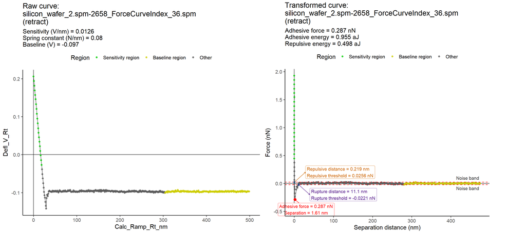

```r
plot_a_curve_metrics(
  fdobj = test,
  curve_name = example1.name,
  useCurve = "retract",plot_raw = T,base_size = 15,annotation_text_size = 4
)
```

```r
plot_all_curve_metrics(
  fdobj = test,
  useCurve = "retract",plot_raw = T,
  destination_folder = './test_plot_metrics',
  format = 'png',width = 18,
    height = 9,
)
```

# Summary statistics of analytical metrics

## Violin plot of selected metrics by surface

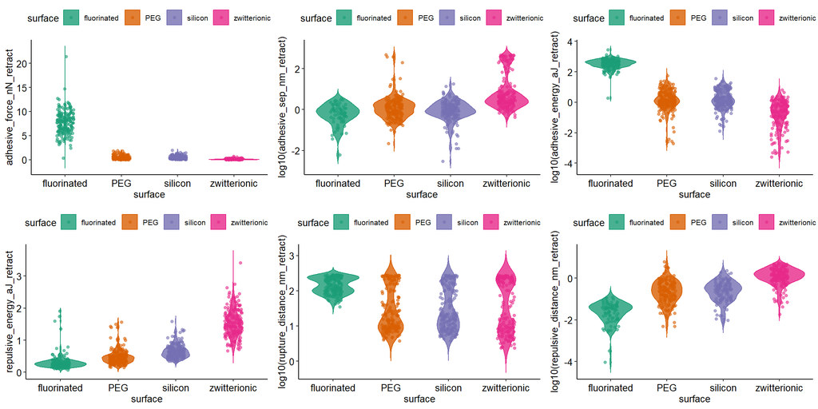

```r
f1 = plot_metric_violin(test@metadata, metric_name = "adhesive_force_nN_retract", group_by = "surface", color_map = c(PEG = "#1b9e77", silicon = "#d95f02", fluorinated = "#7570b3", zwitterionic = "#e7298a"))
f2 = plot_metric_violin(test@metadata, metric_name = "adhesive_sep_nm_retract", log10=T, group_by = "surface", color_map = c(PEG = "#1b9e77", silicon = "#d95f02", fluorinated = "#7570b3", zwitterionic = "#e7298a"))
f3 = plot_metric_violin(test@metadata, metric_name = "adhesive_energy_aJ_retract",log10=T,  group_by = "surface", color_map = c(PEG = "#1b9e77", silicon = "#d95f02", fluorinated = "#7570b3", zwitterionic = "#e7298a"))
f4 = plot_metric_violin(test@metadata, metric_name = "repulsive_energy_aJ_retract", group_by = "surface", color_map = c(PEG = "#1b9e77", silicon = "#d95f02", fluorinated = "#7570b3", zwitterionic = "#e7298a"))
f5 = plot_metric_violin(test@metadata, metric_name = "rupture_distance_nm_retract", log10=T, group_by = "surface", color_map = c(PEG = "#1b9e77", silicon = "#d95f02", fluorinated = "#7570b3", zwitterionic = "#e7298a"))
f6 = plot_metric_violin(test@metadata, metric_name = "repulsive_distance_nm_retract", log10=T, group_by = "surface", color_map = c(PEG = "#1b9e77", silicon = "#d95f02", fluorinated = "#7570b3", zwitterionic = "#e7298a"))

plot_grid(f1,f2,f3,f4,f5,f6, nrow = 2)
```

## Violin plot with statistical annotations

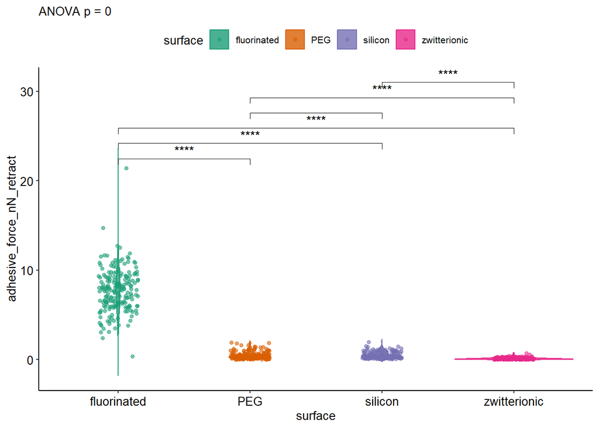

```r
plot_metric_violin(
  df = test@metadata,
  metric_name = "adhesive_force_nN_retract",
  group_by = "surface",
  color_by = "surface",
  color_map = c(
    PEG = "#1b9e77",
    silicon = "#d95f02",
    fluorinated = "#7570b3",
    zwitterionic = "#e7298a"
  ),
  global_test = "anova",
  pairwise_test = "t.test",
  p_adjust_method = "BH"
)
```

## PCA biplot of selected metrics

```
## Dropped 31 row(s) with missing/non-finite feature values or missing color group.
```

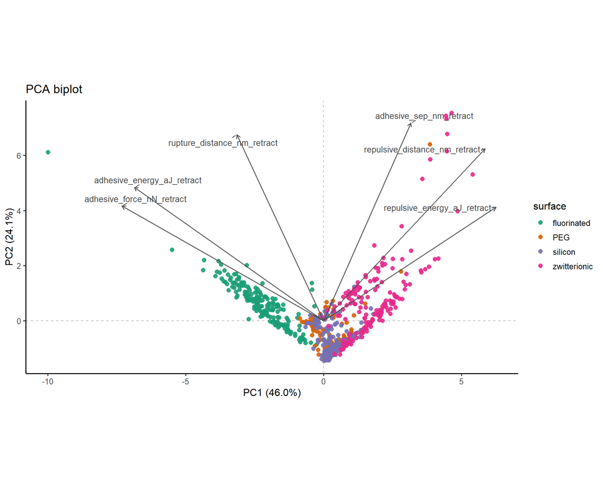

```r
pca_features <- c(
  "adhesive_force_nN_retract",
  "adhesive_sep_nm_retract",
  "adhesive_energy_aJ_retract",
  "repulsive_energy_aJ_retract",
  "rupture_distance_nm_retract",
  "repulsive_distance_nm_retract"
)

plot_pca_biplot(
  df = test@metadata,
  include_columns = pca_features,
  color_by = "surface",
  color_map = c(
    PEG = "#1b9e77",
    silicon = "#d95f02",
    fluorinated = "#7570b3",
    zwitterionic = "#e7298a"
  ),
  arrow_scale = 1.1,
  show_feature_labels = TRUE
)
```

## Scaled feature heatmap with sample annotations

The function `plot_complex_heatmap()` scales each selected feature by row (z-score), plots features as rows and samples as columns, and can annotate columns by up to two metadata variables.

```
## Dropped 31 row(s) with missing/non-numeric feature values.
```

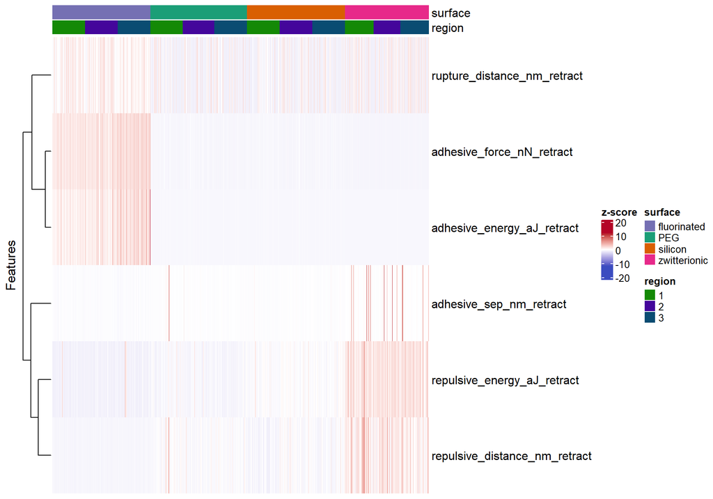

```r
heatmap_features <- c(
  "adhesive_force_nN_retract",
  "adhesive_sep_nm_retract",
  "adhesive_energy_aJ_retract",
  "repulsive_energy_aJ_retract",
  "rupture_distance_nm_retract",
  "repulsive_distance_nm_retract"
)

  plot_complex_heatmap(
    df = test@metadata,
    include_columns = heatmap_features,
    annotate_columns = c("surface", "region"),
    annotation_colors = list(
      surface = c(
        PEG = "#1b9e77",
        silicon = "#d95f02",
        fluorinated = "#7570b3",
        zwitterionic = "#e7298a"
      )
    ),
    cluster_rows = TRUE,
    cluster_columns = FALSE,
    show_row_dend = TRUE,
    show_column_dend = FALSE,
    heatmap_name = "z-score",
    show_column_names = FALSE
  )
```